# El Paso Wasterwater Surveillance Time Series Analysis

#### Explorary analysis with the the WW concentration

```r
#subset the data
sub<- organized.data[ which(organized.data$`WWTP Site`=='Fred Hurvey') ,]
FH<-subset(organized.data , `WWTP Site`=="Fred Hurvey", select = c("WWTP Site", "Date Collected", "N1 Cт", "N2 CT"))
Has<-subset(organized.data , `WWTP Site`=="Haskell", select = c("WWTP Site", "Date Collected", "N1 Cт", "N2 CT"))
Jth<-subset(organized.data , `WWTP Site`=="John T. Hickerson", select = c("WWTP Site", "Date Collected", "N1 Cт", "N2 CT"))
Rb<-subset(organized.data , `WWTP Site`=="Roberto Bustamante", select = c("WWTP Site", "Date Collected", "N1 Cт", "N2 CT"))
```

For the figures below I modified the following 1) legends shortened to “N1” and “N2” and 2) no need to plot all dates - I modified to print every 4 weeks in the label.

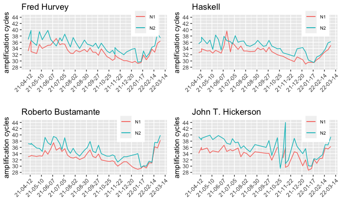

```r
FH.h<-FH[,2:4]
FH.h<- na.omit(FH.h)
FH.h$`Date Collected` <- as.Date(FH.h$`Date Collected`, format = "%Y-%m-%d")
FH.ts <- xts(x = FH.h[,-1], order.by = FH.h$`Date Collected`)


Has<- na.omit(Has)
Has$`Date Collected` <- as.Date(Has$`Date Collected`, format = "%Y-%m-%d")
Has.ts <- xts(x = Has[,c(2:4)], order.by = Has$`Date Collected`)


Jth<- na.omit(Jth)
Jth$`Date Collected` <- as.Date(Jth$`Date Collected`, format = "%Y-%m-%d")
Jth.ts <- xts(x = Jth[,c(2:4)], order.by = Jth$`Date Collected`)


Rb<- na.omit(Rb)
Rb$`Date Collected` <- as.Date(Rb$`Date Collected`, format = "%Y-%m-%d")
Rb.ts <- xts(x = Rb[,c(2:4)], order.by = Rb$`Date Collected`)
plot.Rb<-dygraph(Rb.ts,main="Roberto Bustamante")


break.vec <- c(seq(from = as.Date("2021-04-07"), to = as.Date("2022-03-02"), by = "week"))

p.F <- ggplot(FH.h, aes(x=`Date Collected`))+
            geom_line(aes(y = `N1 Cт`, colour = "N1")) +
              geom_line(aes(y=`N2 CT`,colour="N2"))+
  scale_y_continuous(breaks = scales::pretty_breaks(n = 10),limits = c(28,44))

### here instead of print every week,
a <-p.F+labs(title="Fred Hurvey",x ="", y = "amplification cycles",colour=NULL)+
  scale_x_date(breaks = break.vec, date_breaks="4 weeks", date_labels = "%y-%m-%d")+
  theme(legend.position=c(0.85,0.9),legend.text = element_text(size=7),
        axis.text.x =element_text (angle=45,hjust=1))


p.H<-ggplot(Has, aes(x=`Date Collected`))+
  geom_line(aes(y = `N1 Cт`, colour = "N1")) +
  geom_line(aes(y=`N2 CT`,colour="N2"))+scale_y_continuous(breaks = scales::pretty_breaks(n = 10),limits = c(28,44))

b<-p.H+labs(title="Haskell",x ="", y = "amplification cycles",colour=NULL)+
  scale_x_date(breaks = break.vec, date_breaks="4 weeks", date_labels = "%y-%m-%d")+
  theme(legend.position=c(0.85,0.9),legend.text = element_text(size=7),axis.text.x =element_text (angle=45,hjust=1))


p.R<-ggplot(Rb, aes(x=`Date Collected`))+
  geom_line(aes(y = `N1 Cт`, colour = "N1")) +
  geom_line(aes(y=`N2 CT`,colour="N2"))+
  scale_y_continuous(breaks = scales::pretty_breaks(n = 10),limits = c(28,44))

c<-p.R+labs(title="Roberto Bustamante",x ="", y = "amplification cycles",colour=NULL)+
  scale_x_date(breaks = break.vec, date_breaks="4 weeks", date_labels = "%y-%m-%d")+ theme(legend.position=c(0.75,0.9),legend.text = element_text(size=7),axis.text.x =element_text (angle=45,hjust=1))


p.J<-ggplot(Jth, aes(x=`Date Collected`))+
  geom_line(aes(y = `N1 Cт`, colour = "N1")) +
  geom_line(aes(y=`N2 CT`,colour="N2"))+
  scale_y_continuous(breaks = scales::pretty_breaks(n = 10),limits = c(28,44))

d<-p.J+labs(title="John T. Hickerson",x ="", y = "amplification cycles",colour=NULL)+
  scale_x_date(breaks = break.vec, date_breaks="4 weeks", date_labels = "%y-%m-%d")+
  theme(legend.position=c(0.85,0.9), legend.text = element_text(size=7),axis.text.x =element_text (angle=45,hjust=1))

ggarrange(a,b,c,d, ncol = 2, nrow = 2)
```

```r
#align the date's name
names(Rb)[names(Rb) == "Date Collected"] <- "Date"
names(FH.h)[names(FH.h) == "Date Collected"] <- "Date"
names(Jth)[names(Jth) == "Date Collected"] <- "Date"
names(Has)[names(Has) == "Date Collected"] <- "Date"
```

### Time series analysis with the reported number of cases

Looking I see the variable names still need additional cleaning.

```r
#loading and cleaning case dataset
my_data2 <- read_excel("WWTP_ZCTA_3-3-22 (3).xlsx",sheet="WWTP Normalized",col_names = FALSE)
#str(my_data2)
#t(my_data2)
myData.df <- as.data.frame(t(my_data2), stringsAsFactors=FALSE)
names(myData.df) <- myData.df[2,]
myData.df<-myData.df[-1:-2,c(-2,-7,-8)]
myData.df$Date<-excel_numeric_to_date(as.numeric(as.character(myData.df$Date)), date_system = "modern")
dplr <- full_join(Rb, myData.df, by=c("Date"))
```

For the figures, can we over lay the WW time series and the case data (perhaps case data y-axis on the right), to see how the trends correlate? Looks like we need to do this for each facility (i.e., Fred Hurvey, Haskell etc)

```
Removed 1 row(s) containing missing values (geom_path).Removed 1 row(s) containing missing values (geom_path).Removed 1 row(s) containing missing values (geom_path).Removed 1 row(s) containing missing values (geom_path).
```

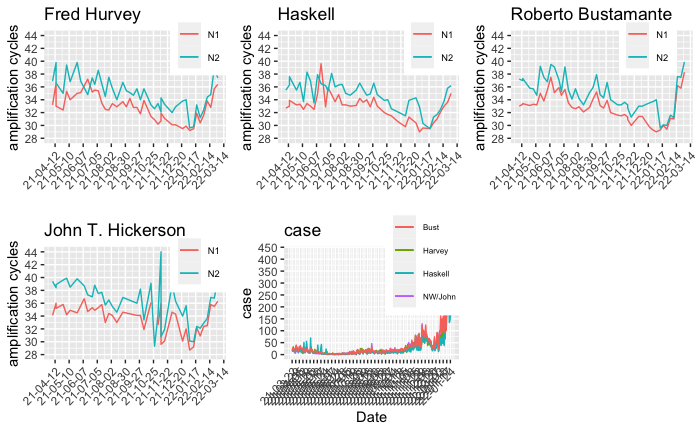

```r
myData.df$Hervey<-as.numeric(myData.df$Hervey)
myData.df$`NW/John T.`<-as.numeric(myData.df$`NW/John T.`)
myData.df$Haskell<-as.numeric(myData.df$Haskell)
myData.df$Bustamante<-as.numeric(myData.df$Bustamante)
break.vec <- c(seq(from = as.Date("2021-03-22"), to = as.Date("2022-1-27"),by = "week"))

case <- ggplot(myData.df, aes(x=Date))+
  geom_line(aes(y = `NW/John T.`, colour = "NW/John"))+geom_line(aes(y=Hervey,colour="Harvey"))+geom_line(aes(y=Haskell,colour="Haskell"))+geom_line(aes(y=Bustamante,colour="Bust"))+scale_y_continuous(breaks = scales::pretty_breaks(n = 10))


timeseries.case<-case+labs(title="case",x ="Date", y = "case",colour=NULL)+scale_x_date(breaks = break.vec, date_labels = "%y-%m-%d")+ theme(legend.position=c(0.8,0.9),legend.text = element_text(size=6),axis.text.x =element_text (angle=45,hjust=1))

ggarrange(a,b,c,d,timeseries.case, ncol = 3, nrow = 2)
```